# Block 2 ex 2

Facchin Tommaso

For unknown reasons, dairy cows sometimes become recumbent, meaning they lie down and are unable to rise. This condition is known as **Downer Cow Syndrome**, and these cows often suffer from a severe illness that can lead to death. The dataset **‘downer.csv’** contains data from a study on blood samples collected from over 400 downer cows examined at the **Ruakura New Zealand Animal Health Laboratory** during the period **1983–1984**.  
Various blood tests were performed, and for many of the animals, the outcome (survived, died, or euthanized) was recorded. The goal is to determine whether **survival can be predicted from blood measurements**. The data were collected from veterinary records, and not all variables were recorded for every cow.

The dataset (taken from *Applied Linear Regression* by S. Weisberg) contains the following variables:  
- **calving**: a factor with levels *before* and *after*  
- **daysrec**: Days recumbent  
- **ck**: Serum creatine phosphokinase (U/l at 30°C)  
- **ast**: Serum aspartate aminotransferase (U/l at 30°C)  
- **urea**: Serum urea (mmol/l)  
- **pcv**: Packed Cell Volume (Hematocrit)  
- **inflat**: Inflammation (0 = no, 1 = yes)  
- **myopathy**: Muscle disorder, a factor with levels *present* and *absent*  
- **outcome**: a factor with levels *died* and *survived*

```r
downer <- read.table("../Datasets/Downer.csv", sep=",", header = TRUE)
head(downer)
```

```
##   calving daysrec    ck  ast urea pcv inflamat myopathy  outcome
## 1   after       1  3000  590 10.9  41       no     <NA> survived
## 2   after       4 12100 1240 23.8  NA     <NA>  present survived
## 3   after       0   600  207  8.1  31      yes     <NA>     died
## 4   after       1   590  113 14.6  43     <NA>     <NA>     died
## 5   after       2  1800  243 12.3  48     <NA>   absent     died
## 6  before       6   380  150   NA  28      yes   absent     died
```

```r
table(downer$outcome, useNA = "ifany")
```

```
##
##     died survived
##      269      166
```

### 1. Compute the sample proportion of cows that survive and derive the corresponding log-odds ratio value. Compare this value with the estimate of the intercept obtained from a GLM with binomial distribution in which no predictors are used. Use the level survived as the level whose probability of occurrence is of interest.

```r
p_hat <- mean(downer$outcome == "survived")
p_hat
```

```
## [1] 0.3816092
```

```r
logit_p <- log(p_hat / (1 - p_hat))
logit_p
```

```
## [1] -0.4827236
```

```r
downer$out <- I(downer$outcome == "survived")

fit0 <- glm(out ~ 1, family = binomial, data = downer)
summary(fit0)
```

```
##
## Call:
## glm(formula = out ~ 1, family = binomial, data = downer)
##
## Coefficients:
##             Estimate Std. Error z value Pr(>|z|)
## (Intercept)  -0.4827     0.0987  -4.891    1e-06 ***
## ---
## Signif. codes:  0 '***' 0.001 '**' 0.01 '*' 0.05 '.' 0.1 ' ' 1
##
## (Dispersion parameter for binomial family taken to be 1)
##
##     Null deviance: 578.42  on 434  degrees of freedom
## Residual deviance: 578.42  on 434  degrees of freedom
## AIC: 580.42
##
## Number of Fisher Scoring iterations: 4
```

```r
coef(fit0)[1]
```

```
## (Intercept)
##  -0.4827236
```

### 2. Estimate a GLM for the variable outcome using ast as a predictor. Plot/visualize the relationship between the variables, also showing the estimated probability that a cow survives as a function of its ast level.

```r
fit1 <- glm(out ~ ast, family = binomial, data = downer)
summary(fit1)
```

```
##
## Call:
## glm(formula = out ~ ast, family = binomial, data = downer)
##
## Coefficients:
##               Estimate Std. Error z value Pr(>|z|)
## (Intercept)  0.5222213  0.1695120   3.081  0.00206 **
## ast         -0.0032394  0.0005198  -6.232  4.6e-10 ***
## ---
## Signif. codes:  0 '***' 0.001 '**' 0.01 '*' 0.05 '.' 0.1 ' ' 1
##
## (Dispersion parameter for binomial family taken to be 1)
##
##     Null deviance: 569.75  on 428  degrees of freedom
## Residual deviance: 499.84  on 427  degrees of freedom
##   (6 osservazioni eliminate a causa di valori mancanti)
## AIC: 503.84
##
## Number of Fisher Scoring iterations: 5
```

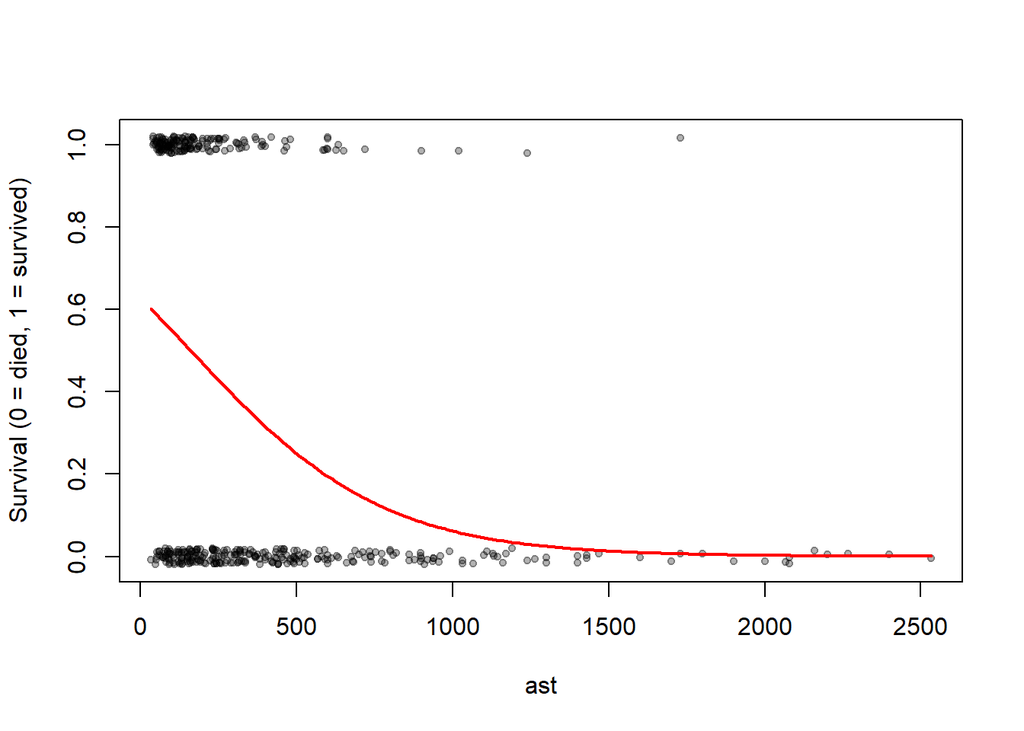

```r
ast_seq <- seq(min(downer$ast, na.rm = TRUE),
               max(downer$ast, na.rm = TRUE),
               length.out = 200)

newdat <- data.frame(ast = ast_seq)

newdat$phat <- predict(fit1, newdata = newdat, type = "response")

plot(downer$ast, jitter(as.numeric(downer$out), amount=0.02),
     xlab = "ast",
     ylab = "Survival (0 = died, 1 = survived)",
     pch = 20, col = rgb(0, 0, 0, 0.3))

lines(newdat$ast, newdat$phat,
      col = "red", lwd = 2)
```

### 3. Now estimate a model in which the only predictor used is urea. Compare the goodness of fit of this model with that of the model estimated in point 2.

```r
fit2 <- glm(out ~ urea, family = binomial, data = downer)
summary(fit2)
```

```
##
## Call:
## glm(formula = out ~ urea, family = binomial, data = downer)
##
## Coefficients:
##             Estimate Std. Error z value Pr(>|z|)
## (Intercept)  0.60434    0.28417   2.127   0.0334 *
## urea        -0.12116    0.03102  -3.906 9.39e-05 ***
## ---
## Signif. codes:  0 '***' 0.001 '**' 0.01 '*' 0.05 '.' 0.1 ' ' 1
##
## (Dispersion parameter for binomial family taken to be 1)
##
##     Null deviance: 354.17  on 265  degrees of freedom
## Residual deviance: 331.11  on 264  degrees of freedom
##   (169 osservazioni eliminate a causa di valori mancanti)
## AIC: 335.11
##
## Number of Fisher Scoring iterations: 5
```

Both models show a significant negative effect of the predictor (higher values -> lower survival probability), but the model with `urea` has a clearly smaller residual deviance and AIC, so—among the cows with non-missing `urea`—it provides a **better** fit to the data than the model with `ast`.

### 4. Using the model identified as best in point 3, estimate the probability that the cows with characteristics given in the dataset nd survive, and provide a 92% confidence interval for the estimated probability.

```r
nd <- data.frame(ast = c(500, 1400,2000),
urea = c(5, 20, 30))

pred <- predict(fit2, newdata=nd, type = "link", se.fit = TRUE)

fit <- pred$fit
se.fit <- pred$se.fit

cbind(binomial()$linkinv(fit + qnorm(.04) * se.fit),
      binomial()$linkinv(fit + qnorm(.96) * se.fit))
```

```
##         [,1]      [,2]
## 1 0.42873915 0.5705521
## 2 0.07563871 0.2433379
## 3 0.01420190 0.1393544
```